# Weight Lifting Exercise Predictions

Kirk Shanks

Sunday, September 21, 2014

### Synopsis

Using devices such as Jawbone Up, Nike FuelBand, and Fitbit it is now possible to collect a large amount of data about personal activity relatively inexpensively. These type of devices are part of the quantified self movement - a group of enthusiasts who take measurements about themselves regularly to improve their health, to find patterns in their behavior, or because they are tech geeks. One thing that people regularly do is quantify how much of a particular activity they do, but they rarely quantify how well they do it. In this project, your goal will be to use data from accelerometers on the belt, forearm, arm, and dumbell of 6 participants. They were asked to perform barbell lifts correctly and incorrectly in 5 different ways. More information is available from the website here: (http://groupware.les.inf.puc-rio.br/har) (see the section on the Weight Lifting Exercise Dataset).

#### Loading and preprocessing the data

The data set is the [Weight Lifting Dataset](https://d396qusza40orc.cloudfront.net/predmachlearn/pml-training.csv) [11.6 Mb].

#### Read in the data

Read in the data and preprocess:

```r
fileURL <- "https://d396qusza40orc.cloudfront.net/predmachlearn/pml-training.csv"
destfile <- "data/pml-training.csv"

download.file(fileURL, destfile)

pml.training <- read.csv("data/pml-training.csv")
```

Next, we need to divide the data into training and test sets.

```r
library(ggplot2)
library(knitr)
library(caret)
inTrain <- createDataPartition(y = pml.training$classe, p = 0.7, list = FALSE)
training <- pml.training[inTrain,]
testing <- pml.training[-inTrain,]
```

I then removed all columns that had a zero or near zero variance, the columns with NAs as well as the participants names and the time stamps.

```r
# Remove columns with Near Zero Variance
nzv <- nearZeroVar(training[,-160], freqCut = 95/5, uniqueCut = 10, saveMetrics = FALSE)
training <- training[,-nzv]


# Remove the columns with NAs
# I am also removing the timestamps and user names columns
training <- subset(training, select=colMeans(is.na(training)) == 0)
training <- training[,-(1:6)]
```

This results in a training set with a size of:

```r
dim(training)
```

```
## [1] 13737    53
```

### Model Fit

For the model fit algorithms, I chose to use two methods; random forests and boosting.

## Random Forest

I used 250 trees to limit computation time.

```r
# Model Fit
    # Random Forest
        library(randomForest)
        set.seed(7777777)
        modFit.rf <- randomForest(classe ~.,
                                  ntree = 250,
                                  data = training)

        # Predicting new values
        pred.rf <- predict(modFit.rf, testing)
        testing$predRight.rf <- pred.rf == testing$classe
```

## Boosting

```r
    # Boosting

        library(ISLR)
        set.seed(7777777)
        modFit.gbm <- train(classe ~.,
                            method = "gbm",
                            data = training,
                            verbose=FALSE)
        # Predicting new values
        pred.gbm <- predict(modFit.gbm, testing)
        testing$predRight.gbm <- pred.gbm == testing$classe
```

### Results

The random forest model resulted in 0.9941 accuracy with the boosting resulted in 0.9592 accuracy.

```r
table(pred.rf, testing$classe)
```

```
##
## pred.rf    A    B    C    D    E
##       A 1671    9    0    0    0
##       B    1 1129    7    0    0
##       C    2    1 1017    9    0
##       D    0    0    2  955    4
##       E    0    0    0    0 1078
```

```r
modFit.rf
```

```
##
## Call:
##  randomForest(formula = classe ~ ., data = training, ntree = 250)
##                Type of random forest: classification
##                      Number of trees: 250
## No. of variables tried at each split: 7
##
##         OOB estimate of  error rate: 0.57%
## Confusion matrix:
##      A    B    C    D    E class.error
## A 3900    4    0    0    2    0.001536
## B   11 2640    7    0    0    0.006772
## C    0   18 2375    3    0    0.008765
## D    0    0   27 2224    1    0.012433
## E    0    0    1    4 2520    0.001980
```

```r
table(pred.gbm, testing$classe)
```

```
##
## pred.gbm    A    B    C    D    E
##        A 1643   50    0    0    3
##        B   19 1058   36    2   15
##        C    9   29  982   30   11
##        D    1    1    7  926   17
##        E    2    1    1    6 1036
```

```r
modFit.gbm
```

```
## Stochastic Gradient Boosting
##
## 13737 samples
##    52 predictor
##     5 classes: 'A', 'B', 'C', 'D', 'E'
##
## No pre-processing
## Resampling: Bootstrapped (25 reps)
##
## Summary of sample sizes: 13737, 13737, 13737, 13737, 13737, 13737, ...
##
## Resampling results across tuning parameters:
##
##   interaction.depth  n.trees  Accuracy  Kappa  Accuracy SD  Kappa SD
##   1                   50      0.8       0.7    0.006        0.008
##   1                  100      0.8       0.8    0.006        0.007
##   1                  150      0.8       0.8    0.005        0.007
##   2                   50      0.9       0.8    0.005        0.007
##   2                  100      0.9       0.9    0.005        0.006
##   2                  150      0.9       0.9    0.004        0.005
##   3                   50      0.9       0.9    0.006        0.007
##   3                  100      0.9       0.9    0.005        0.006
##   3                  150      1.0       0.9    0.004        0.005
##
## Tuning parameter 'shrinkage' was held constant at a value of 0.1
## Accuracy was used to select the optimal model using  the largest value.
## The final values used for the model were n.trees = 150,
##  interaction.depth = 3 and shrinkage = 0.1.
```

# Random Forests

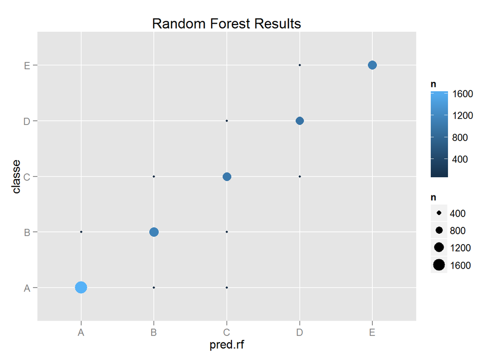

```r
        # Plot the results
        p <- ggplot(testing, aes(pred.rf, classe))
        p + stat_sum(aes(size = ..n.., col = ..n..)) +
                ggtitle("Random Forest Results")
```

# Boosting

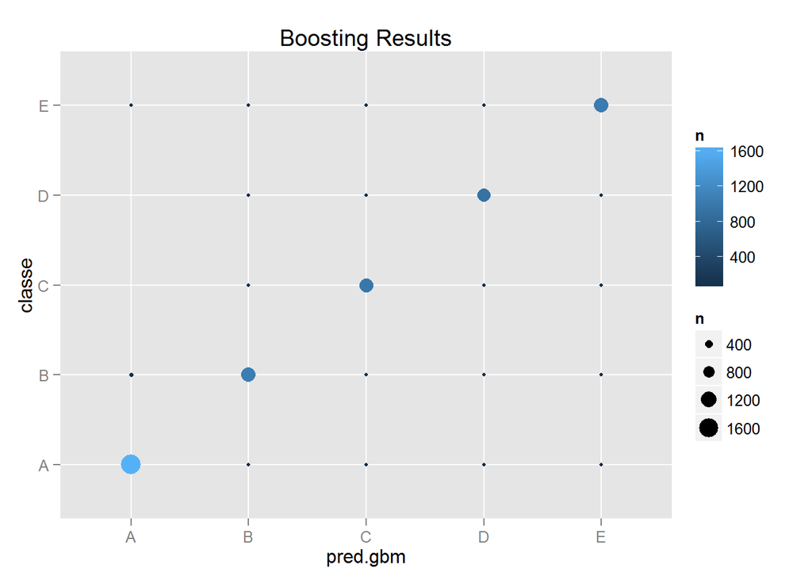

```r
        # Plot the results
        p <- ggplot(testing, aes(pred.gbm, classe))
        p + stat_sum(aes(size = ..n.., col = ..n..)) +
                ggtitle("Boosting Results")
```